# 3. 나이브 베이즈 및 HMM 실습

# 붓꽃 데이터

Scikit-Learn 패키지에는 150 송이의 붓꽃(iris)에 대한 데이터가 있다. 꽃받침(sepal) 길이, 꽃받침 너비, 꽃잎(petal) 길이, 꽃잎 너비, 그리고 세 종류의 품종에 대한 정보가 담겨있다.

[output not shown]

먼저 데이터 분석에 필요한 시각화 패키지 seaborn과 matplotlib을 불러오자.

```python
import seaborn as sns # seaborn 패키지를 sns라는 오브젝트에 저장
import matplotlib.pyplot as plt
```

이후 seaborn 패키지의 load_dataset 함수를 이용해 내장된 iris 데이터를 불러오자.

```python
iris = sns.load_dataset("iris") # load iris data

iris
```

|  | sepal_length | sepal_width | petal_length | petal_width | species |
| --- | --- | --- | --- | --- | --- |
| 0 | 5.1 | 3.5 | 1.4 | 0.2 | setosa |
| 1 | 4.9 | 3.0 | 1.4 | 0.2 | setosa |
| 2 | 4.7 | 3.2 | 1.3 | 0.2 | setosa |
| 3 | 4.6 | 3.1 | 1.5 | 0.2 | setosa |
| 4 | 5.0 | 3.6 | 1.4 | 0.2 | setosa |
| ... | ... | ... | ... | ... | ... |
| 145 | 6.7 | 3.0 | 5.2 | 2.3 | virginica |
| 146 | 6.3 | 2.5 | 5.0 | 1.9 | virginica |
| 147 | 6.5 | 3.0 | 5.2 | 2.0 | virginica |
| 148 | 6.2 | 3.4 | 5.4 | 2.3 | virginica |
| 149 | 5.9 | 3.0 | 5.1 | 1.8 | virginica |

150 rows × 5 columns

4가지 변수 중 품종 별 꽃잎 길이를 히스토그램으로 나타내보자.

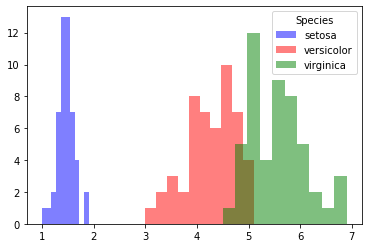

```python
plt.hist(iris[iris.species == "setosa"]["petal_length"], color="blue",alpha=0.5,
         label="setosa")
plt.hist(iris[iris.species == "versicolor"]["petal_length"], color="red",alpha=0.5,
        label="versicolor")
plt.hist(iris[iris.species == "virginica"]["petal_length"], color="green",alpha=0.5,
        label="virginica")
plt.legend(title="Species")
plt.show()
```

- 위의 그래프를 살펴보면 각 품종별로 데이터가 군집을 이룸을 관찰할 수 있다.
- 그렇다면 품종에 대한 정보가 없이 관측한 꽃잎의 길이만으로 같은 품종끼리 구분해낼 수 있을까?

# 가우시안 혼합모형과 EM알고리즘

### E-step

\begin{eqnarray} \lambda_j(X_i,\theta)&=&P(K_i=j \mid X_i,\theta)\\ &=& \dfrac{P(K_i=j)P(X_i\mid K_i=j, \theta)}{P(X_i|\theta)} \\ &=& \dfrac{P(K_i=j)P(X_i\mid K_i=j, \theta)}{\sum_{k=1}^3 P(X_i,K_i=k|\theta)} \\ &=& \dfrac{P(K_i=j)P(X_i\mid K_i=j, \theta)}{\sum_{k=1}^3 P(K_i=k)P(X_i\mid z_i=k, \theta)}\\ &=& \dfrac{w_j N(\mu_j,\sigma_j)}{\sum_{k=1}^3 w_k N(\mu_k,\sigma_k)} \end{eqnarray}

### M-step

- $$ \mu_j = \dfrac{1}{N_j} \sum_{i=1}^N X_i\lambda_j(X_i,\theta)$$
- $$ \sigma_j = \dfrac{1}{N_j} \sum_{i=1}^n (X_i-\mu_j)^2\lambda_j(X_i,\theta) $$
- $$ w_j=\frac{1}{n}\sum_{i=1}^{n}{\lambda_j(X_i,\theta)}$$

$\;\;\;\;,where \; N_j = \sum_{i=1}^n \lambda_j(X_i,\theta). $

- scikitlearn 에는 여러 혼합모형에 대한 함수들을 제공한다.
- 내장된 함수를 이용하여 군집분석을 시행해보자.

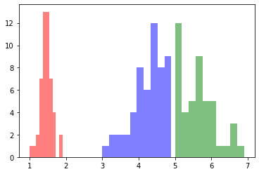

```python
from sklearn import mixture

# GMM 모형 fit
gmm_iris=mixture.GaussianMixture(n_components=3).fit(iris[['petal_length']]) # n_component : 군집의 수

# pred_gmm_iris 에는 각 데이터별 예측된 군집의 정보 (0,1,2) 가 담겨있다.
pred_gmm_iris=gmm_iris.predict(iris[['petal_length']])


iris['gmm_pred']=pred_gmm_iris

# 예측된 군집별 plot 그리기
plt.hist(iris[iris.gmm_pred == 0]["petal_length"], color="blue",alpha=0.5)
plt.hist(iris[iris.gmm_pred == 1]["petal_length"], color="red",alpha=0.5)
plt.hist(iris[iris.gmm_pred == 2]["petal_length"], color="green",alpha=0.5)

plt.show()
```

- 앞선 실제 그래프와 비교했을 때 군집분석이 잘 이루어진 것으로 보인다.
- 실제 데이터와 얼마나 일치하는지 구체적으로 나타내면 다음과 같다.

```python
from sklearn import metrics

iris_gmm_score = metrics.adjusted_rand_score(iris['species'],pred_gmm_iris)

# Print the score
iris_gmm_score
```

```
0.8509627406851713
```

## 전체 데이터를 이용한 군집분석

- 이제 꽃잎의 길이 뿐만 아니라 나머지 3가지 변수(꽃잎의 너비, 꽃받침의 너비, 길이)를 모두 이용해 군집분석을 해보자. 먼저 네 변수간의 그래프를 그리면 다음과 같다.

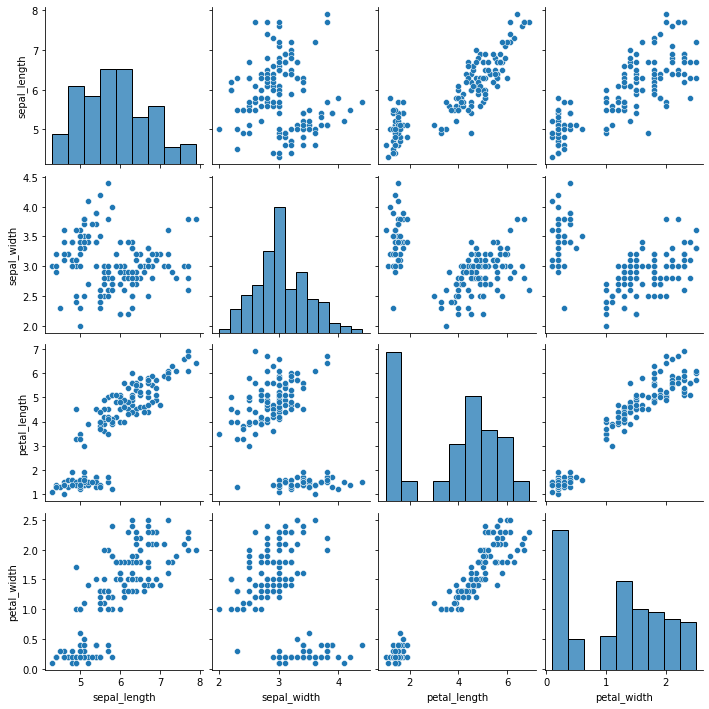

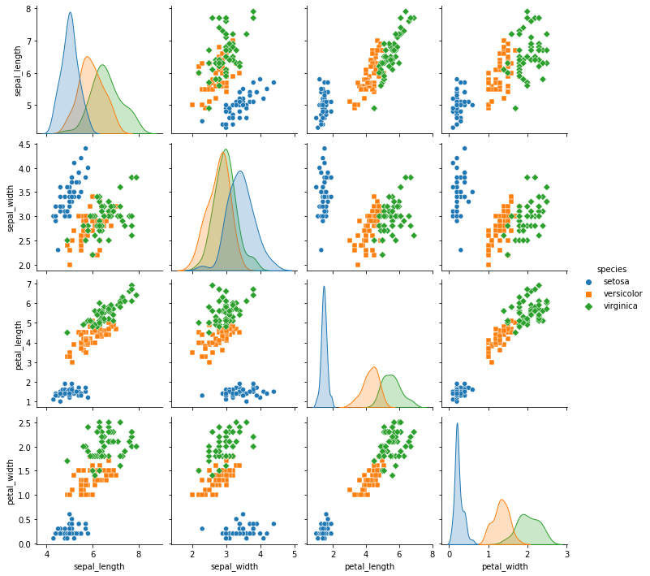

```python
# data load
iris = sns.load_dataset("iris")

# 품종구분 X
sns.pairplot(iris)

# 품종구분 O
sns.pairplot(iris, hue="species", markers=["o", "s", "D"])
```

- 강의에서는 1차원 데이터에 대한 군집분석만을 다루었지만 4개의 변수로 이루어진 4차원 데이터에 대해서도 군집분석을 시행할 수 있다. (이때 모수의 추정에는 다변량 가우시안 분포함수를 사용한다.)
- 이전과 마찬가지로 GaussianMixture 함수를 이용하여 군집분석을 시행해보자.

```
0.9038742317748124
```

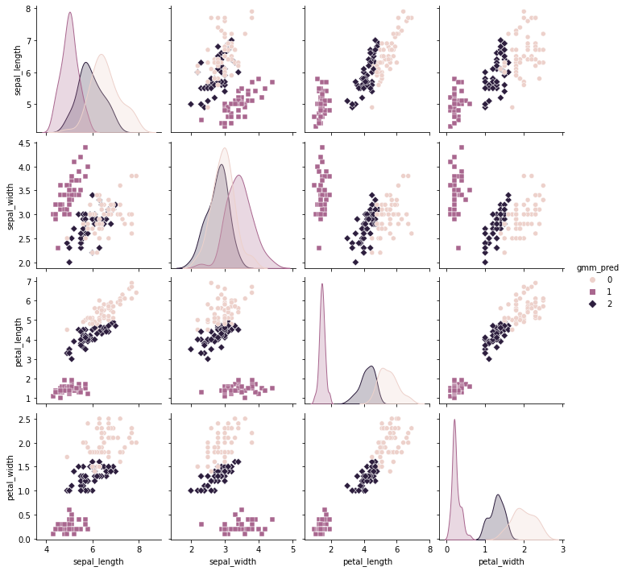

```python
gmm_iris_full = mixture.GaussianMixture(n_components=3).fit(iris[['sepal_length','sepal_width','petal_length','petal_width']])
pred_gmm_iris_full = gmm_iris_full.predict(iris[['sepal_length','sepal_width','petal_length','petal_width']])
iris['gmm_pred'] = pred_gmm_iris_full

# 예측된 군집별 plot 그리기
sns.pairplot(iris, hue="gmm_pred", markers=["o", "s", "D"])

# 기존 군집과 일치하는 정도 수치화
iris_gmm_score = metrics.adjusted_rand_score(iris['species'],pred_gmm_iris_full)

# Print the score
iris_gmm_score
```

# 나이브 베이즈를 이용한 분류

- 4장에서 배운 나이브 베이즈를 iris에 적용해보자.
- 가우시안 혼합모형과 달리 나이브 베이즈는 모형을 학습하는 과정에서 각 데이터가 속하는 실제 클래스의 정보가 필요하다.
- scikitlearn 내의 naive_bayes 모듈을 이용하여 iris 데이터에 나이브 베이즈를 적용해보자.
- iris 데이터는 연속형 변수이므로 가우시안 나이브 베이즈, 즉, 각 클래스에서 특성값들의 분포가 정규분포임을 가정한 모형을 사용한다.
- 데이터를 절반(Training set, test set)으로 나누어 training set을 통해 모형학습을, test set을 통해 모형평가를 해보자.

```python
from sklearn.naive_bayes import GaussianNB # Gaussian Naive Bayes
from sklearn.model_selection import train_test_split
train, test = train_test_split(iris, test_size=0.5) #  training set, test set

train_X = train[['sepal_length','sepal_width','petal_length','petal_width']]
train_label = train[['species']] # 실제 품종에 대한 정보
test_X = test[['sepal_length','sepal_width','petal_length','petal_width']]
test_label = test[['species']] # 실제 품종에 대한 정보
```

```python
nb_iris = GaussianNB().fit(train_X, train_label) # training set을 이용한 나이브 베이즈 모형 학습
pred_label = nb_iris.predict(test_X) # 모형을 통해 예측한 test set의 각 품종
pred_prob = nb_iris.predict_proba(test_X) # 데이터가 각 범주에 속할 확률
```

실제 품종과 모형을 통해 예측한 품종, 각 품종에 속할 확률을 test set의 몇 가지 데이터에 대해 나타내면 다음과 같다.

```python
test['pred_label'] = pred_label
test['pred_prob'] = pred_prob.round(3).tolist()
test[['species','pred_label','pred_prob']].head()
```

|  | species | pred_label | pred_prob |
| --- | --- | --- | --- |
| 62 | versicolor | versicolor | [0.0, 1.0, 0.0] |
| 135 | virginica | virginica | [0.0, 0.0, 1.0] |
| 104 | virginica | virginica | [0.0, 0.0, 1.0] |
| 32 | setosa | setosa | [1.0, 0.0, 0.0] |
| 117 | virginica | virginica | [0.0, 0.0, 1.0] |

test set 데이터에 대해 예측된 품종별 plot을 그리면 아래와 같다.

```
0.8488857320429726
```

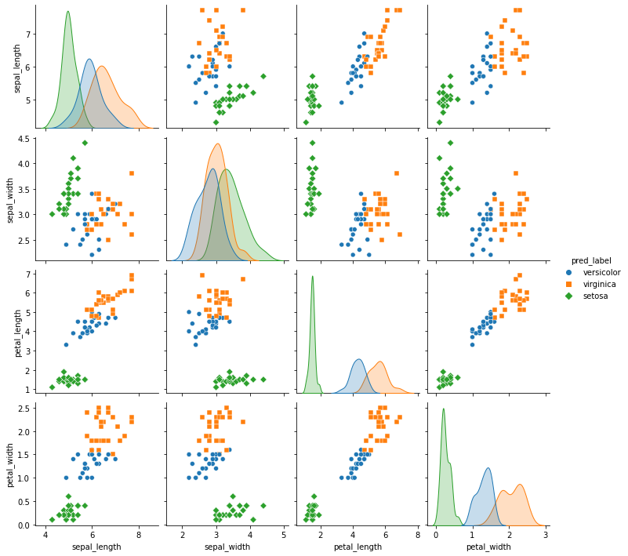

```python
sns.pairplot(test[['sepal_length','sepal_width','petal_length','petal_width','pred_label']], hue="pred_label", markers=["o", "s", "D"])

# 기존 군집과 일치하는 정도 수치화
iris_nb_score = metrics.adjusted_rand_score(test['species'],test['pred_label'])

# # Print the score
iris_nb_score
```

# LGE-SNU DS 고급과정 HMM 실습

HMM 관련 패키지 중 하나인 hmmlearn 패키지를 사용해보자. hmmlearn 패키지에서는 아래와 같은 3가지 형태의 hmm을 제공한다.

| GaussianHMM | HMM with Gaussian emissions. |
| --- | --- |
| GMMHMM | HMM with Gaussian mixture emissions. |
| MultinomialHMM | HMM with multinomial (discrete) emissions. |

강의자료에는 observation이 discrete 인 경우만 소개했지만, continuous 한 경우도 GMMHMM 또는 GaussianHMM 을 이용해서 쉽게 분석할 수 있다. 본 실습에서는 MultinomialHMM와 GaussianHMM을 이용한 분석을 소개한다.

## 1. 관측값이 이산확률변수인 경우

https://en.wikipedia.org/wiki/Template:HMM_example 에 소개된 아래 예시를 이용하여 모형을 분석해보자.

Bob 은 그날의 날씨 (Rainy, Sunny) 에 따라 산책(Walk), 쇼핑(shop), 방청소(clean) 중 하나의 행동을 취한다. Alice 는 Bob 이 그날그날 어떠한 행동을 취했는지만을 알고 있으며, 이를 통해 날씨에 대해 추측을 하고자 한다. 이를 Hidden Markov chain 의 관점에서 보면 날씨 (Rainy, Sunny)는 숨겨진 정보로써 은닉변수에 해당하며, Bob이 취하는 행동은 각 날씨에서 특정 출력확률을 따라 관측되는 값으로 이해할 수 있다.

```python
!pip install hmmlearn
```

```
     |████████████████████████████████| 217 kB 9.1 MB/s
```

```python
from __future__ import division
import numpy as np
from hmmlearn import hmm
import random

states = ('Rainy', 'Sunny')
n_states = len(states)
observations = ('walk', 'shop', 'clean')

# 실제 모형
model_true = hmm.CategoricalHMM(n_components=n_states, init_params = '', params='')# n_components : 은닉변수가 가질 수 있는 값의 개수

# 은닉변수의 초기상태에 대한 확률분포
model_true.startprob_ = np.array([0.6, 0.4])

# 전이확률 행렬
model_true.transmat_ = np.array([
  [0.7, 0.3],
  [0.4, 0.6]
])

# 출력확률 행렬
model_true.emissionprob_ = np.array([
  [0.1, 0.4, 0.5],
  [0.6, 0.3, 0.1]
])
```

```python
random.seed(100)
bob_says, hidden_state = model_true.sample(10) # 크기 10 인 관측값을 랜덤하게 출력
print(bob_says.T)
print("Bob says:", ", ".join(map(lambda x: observations[int(x)], bob_says)))
print("Hidden state:", ", ".join(map(lambda x: states[int(x)], hidden_state)))
```

```
[[0 1 2 1 2 1 2 0 1 2]]
Bob says: walk, shop, clean, shop, clean, shop, clean, walk, shop, clean
Hidden state: Sunny, Sunny, Rainy, Sunny, Rainy, Rainy, Rainy, Sunny, Rainy, Rainy
```

### 학습(Learning) 과 디코딩(Decoding)

hmmlearn 패키지에서는 $\textbf{fit}$ 함수를 이용하여 HMM의 모수 (전이확률($A$), 출력확률($B$), 은닉변수의 초기상태에 대한 확률($\pi$)) 를 추정할 수 있으며, $\textbf{decode}$ 함수를 이용하여 최적의 은닉변수열을 찾을 수 있다.

```python
model_pred = hmm.CategoricalHMM(n_components=n_states, n_iter = 100, tol = 1.0e-2)
model_pred = model_pred.fit(bob_says) # 추정된 모형
```

추정된 모수들은 각각 아래와 같다.

```python
model_pred.transmat_, model_pred.emissionprob_,model_pred.startprob_
```

```
(array([[3.33333335e-01, 6.66666665e-01],
        [1.00000000e+00, 8.53177113e-17]]),
 array([[3.33333333e-01, 6.66666666e-01, 1.45820714e-09],
        [1.28560827e-18, 1.22919702e-16, 1.00000000e+00]]),
 array([1.00000000e+00, 5.76843626e-31]))
```

```python
logprob, hidden_state_pred = model_pred.decode(bob_says, algorithm="viterbi") # viterbi 알고리즘 이용
print("Bob says:", ", ".join(map(lambda x: observations[int(x)], bob_says)))
print("Prediction of hidden state:", ", ".join(map(lambda x: states[int(x)], hidden_state_pred)))
print("Accuracy:",np.mean(hidden_state==hidden_state_pred)) # 실제 날씨와 일치하는 비율
```

```
Bob says: walk, shop, clean, shop, clean, shop, clean, walk, shop, clean
Prediction of hidden state: Rainy, Rainy, Sunny, Rainy, Sunny, Rainy, Sunny, Rainy, Rainy, Sunny
Accuracy: 0.2
```

## 2. 관측값이 연속확률변수인 경우

- 관측값이 이산확률변수인 경우 출력확률 $P(O_t | X_t=j)$ 이 이산확률분포를 나타내었지만, 관측값이 연속확률변수인 경우에는 이러한 접근이 불가능하다.
- 이 경우 출력확률을 연속확률분포로 이해하며, 출력확률행렬 대신 분포의 모수를 추정해야 한다.
- 본 실습에서는 각 출력확률이 Gaussian 인 경우에 대해 다루고자 한다.

```python
# 실제 모형
model_true = hmm.GaussianHMM(n_components=3) # n_components : 은닉변수가 가질 수 있는 값의 개수

# 은닉변수의 초기상태에 대한 확률분포
model_true.startprob_ = np.array([0.5, 0.2, 0.3])

# 전이확률 행렬
model_true.transmat_ = np.array([[0.5, 0.3, 0.2],
                     [0.2, 0.6, 0.2],
                     [0.0, 0.5, 0.5]])

# 각 출력확률분포의 평균
model_true.means_ = np.array([[-1.0],[1.0],[3.0]])

# 각 출력확률분포의 분산
model_true.covars_  = np.array([[1],[1],[1]])
```

```python
observation, hidden_state = model_true.sample(15) # 크기 15 인 관측값을 랜덤하게 출력

print("Observation:",observation.T)
print("Hidden state:",hidden_state)
```

```
Observation: [[ 2.95290622  0.29872754 -2.49317895  0.5199604  -0.56826589 -1.17346098
  -2.65247252  3.32897073  1.16298347 -1.00699968  0.23538078 -2.44754962
  -1.0198038   0.67482836 -2.70681723]]
Hidden state: [2 1 0 1 0 0 0 2 1 0 0 0 0 1 0]
```

```python
model_pred = hmm.GaussianHMM(n_components=3, n_iter = 100, tol = 1.0e-2)
model_pred = model_pred.fit(observation) # 추정된 모형
```

추정된 모수들은 각각 아래와 같다.

```python
model_pred.transmat_, model_pred.means_, model_pred.covars_, model_pred.startprob_
```

```
(array([[2.14670430e-202, 3.34066761e-001, 6.65933239e-001],
        [6.94246732e-187, 6.46017384e-089, 1.00000000e+000],
        [4.43137000e-001, 1.26055439e-018, 5.56863000e-001]]),
 array([[-2.57512583],
        [ 3.14093298],
        [-0.09973458]]),
 array([[[0.01407979]],

        [[0.04035628]],

        [[0.66086016]]]),
 array([0.00000000e+00, 1.00000000e+00, 7.99004623e-25]))
```

```python
logprob, hidden_state_pred = model_pred.decode(observation, algorithm="viterbi") # viterbi 알고리즘 이용
print("Observation:",observation.T)
print("Prediction of hidden state:", hidden_state_pred)
print("Accuracy:",np.mean(hidden_state==hidden_state_pred)) # 실제 은닉변수와 일치하는 비율
```

```
Observation: [[ 2.95290622  0.29872754 -2.49317895  0.5199604  -0.56826589 -1.17346098
  -2.65247252  3.32897073  1.16298347 -1.00699968  0.23538078 -2.44754962
  -1.0198038   0.67482836 -2.70681723]]
Prediction of hidden state: [1 2 0 2 2 2 0 1 2 2 2 0 2 2 0]
Accuracy: 0.26666666666666666
```